# Chapter 7: Bonds

FINA 3000 · Business Finance I · Class 9

Dr. Justin Mohr

September 22, 2026

## Exam

- Oxford had a busy weekend.
- Started this morning. Goal is Wednesday, latest Thursday

## Today’s Agenda

- Discuss Ch6 Material
- Overview of AI
- AI Assignment
  - Announcement: Just doing one part
  - Due the 27th
  - No Part 2

## Ch 6

- That discount rate…
- Where does it come from?

## CH5 definition

- Opportunity cost: Money today can be invested and earn interest.
- Inflation: Money looses value over time.
- Uncertainty: Something could happen? What if you don’t trust me?

## Ch7 is bonds

What is a bond?

A debt, more specifically a debt with scheduled payments of interest and principal returned at the end.

## Bonds are the perfect TVM problem!

- N is how long until the principal is repaid
- P/V is the price of the bond (Or principal if at issuance.)
- PMT is the interest (or coupon payments)
- FV is the principal being returned

## But what about the interest rate?

- Well that should reflect the
  - Inflation
    - Money is worthless in the future
  - Uncertainty and opportunity cost
    - Risk and the return you would get elsewhere for the same risk

## How do we determine interest rates?

- Treasury Bills
  - Auctions
- Corporations
  - Road shows (Similar to IPOs)

## Determinants of Interest Rates

$$r = r^* + IP + MRP + DRP + LP$$

- r*
  - Real risk free rate
- IP
  - Average of inflation expectations
- MRP
  - Long term bonds are more exposed to interest rate changes
- DRP
  - How likely default is
- LP
  - Ability to convert bond to cash

## The government is special

- We believe that the USA will
  - Never Default
  - Always have people to buy its debt
- This means that for t bills
  - DRP and LP are zero
- This means a couple of cool things!

## Credit Spreads

[figure not shown]

## Credit spreads and the stock market

When the credit spread of a company goes up what has changed?

DRP and LP have gone up!

What does this mean for the stock market?

Likely bad things!

## Credit Spreads and Stock Market

- Good times
  - future cash flow growth increases, and default risk decreases → narrower spread and a rising stock market
- Bad times
  - corporate default risk increases → wider spread, and the stock market tends to decline

## Yield Curves

- More cool bond things
- If we plot on the y axis the rate and the x axis the maturity, then we have a yield curve

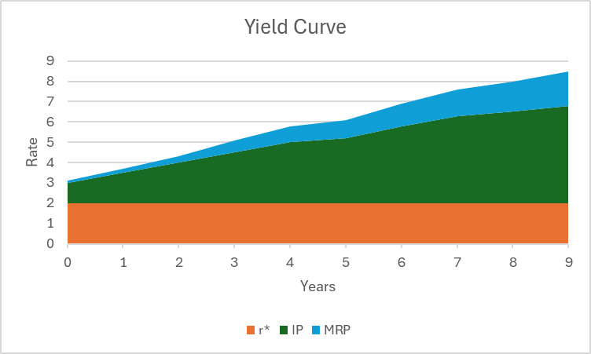

## What can a yield curve tell us?

- Normal times (Expecting future growth)
  - Upward sloping curve
  - Long time means a higher MRP and we expect a certain level of inflation in the economy
  - If you take my money for a long time, I need a higher rate
  - If the economy will grow then the Fed will raise rates, r*

## What can a yield curve tell us?

- Flat Curves (Transition)
  - Economy is changing from either expansion or contraction
  - Can be seen when the Fed raises rates to control a rapidly growing economy
  - Long term rates fall with lower inflation expectations while short-term rates are pushed up by the Fed.

Why does raising rates slow down an economy? What does it do to inflation? Think about discounting.

## What can a yield curve tell us?

- Inverted Curves (Recession)
  - Long term rates are lower than short term rates
  - Means that in the short term rates will be high and lowered in the future to stimulate growth
  - Also demand for longer term debt is high, driving down rates.

Why is this a bad signal?

## To oversimplify

- Last week the Fed raised rates
- We saw short term yields go up and the 10 year go down
- The short term reacted to the Fed raising r* and the long term reacted to lower inflation expectations

## AI

- The School of Business is pushing new AI initiatives
- As a part of that we are doing an AI assignment I figured as a part of that we could have a class discussion on how it works and its limitations

## “Chat said”

- “Claude said,” “Grok said,” “Gemini said”
- Often people appeal to the authority when discussing about the results from AI

But are they correct? Can they be wrong? Talk amongst yourselves for a few minutes and then we will discuss together

## How does an LLM (AI) work?

- To start, make it read everything.
- Then train it to predict the next word given all the things that it has read
- At their core, they are word calculators

## Tokens not Words

- The LLM does not actually think in words, actually it doesn’t think at all
- To generate the response to a question it
  - Predicts the most likely next token
  - Adds it to the sequence
  - Predicts the next one, and so on until it has an answer.
- It might feel instant, but the model is performing this many times per second

## As a source of truth

- Lets look to the legal field
- https://www.damiencharlotin.com/hallucinations

## Why does it do this?

- It doesn’t know not to!
- It can make a case citation look correct, and it can make any argument you request. But it is just guessing on what is the most likely word to be said next.

## AI Assignment

- On blackboard you will find the AI assignment, let us go through together and fill that out

## Next Class

- We will start on Ch7 material

## Upcoming Dates

Upcoming class dates and deadlines

| Date | Topic | Due / Notes |
| --- | --- | --- |
| Thu Sep 24 | Chapter 7: Bonds | - |
| Sun Sep 27 | AI assignment | DUE |
| Tue Sep 29 | Chapter 7: Bonds | - |
| Thu Oct 1 | Chapter 8: Risk and Return | - |

**Office:** 325 Holman Hall · **Office hours:** T TH 10:50A-12:20P · jjmohr1@olemiss.edu